# Anticipatory Action Trigger Mechanism Report

Drought in Niger

Last updated: 2022-10-18

## Key Messages

- ACTIVATION

  There is a 71 - 86% chance that an activation will occur in a given year.
- SHOCK DETECTION

  At least some activities are expected to be implemented ahead of 89 - 100% of shocks.
- FALSE ALARMS

  The risk of activating in the absence of a severe shock stands at 48 - 70% of activations.
- NO REGRETS BIAS

  The mechanism is optimised to reduce the risk of failing to activate when there is a shock, at the cost of having false alarms. Mitigation is recommended to minimise the negative impact of a false alarm due to its moderate to high likelihood.

## About Metric Estimates

The estimates in this report are shown as ranges called confidence intervals. The confidence intervals reflect the probabilistic nature of the estimates as well as the impact of data limitations (small or incomplete datasets, errors or imprecision in measurements, divergences between data sources, etc.) on the accuracy of estimates. They can inform decision-making by illustrating the most likely performance levels and by providing bounds for the possible albeit unlikely extremes.

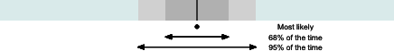

- The central value is the most likely performance;
- Most often the trigger will perform within the darker inner range (68% of the time);
- There is high confidence that the trigger will perform within the full coloured (grey or blue) range (95% of the time).

## Colour Coding

In the visualizations blue represents activation likelihood, green represents desired outcomes (valid non-activations/activations) and red represents undesired outcomes or errors.

## Trigger Mechanism Snapshot

This table summarises the trigger mechanism and its performance in signaling severe shocks. It presents estimates of the likelihood that the threshold would be met in a given year as well as how often the trigger is expected to correctly recommend an activation or non-activation.

Trigger 1

Trigger 2

Trigger 3

**Description**

Type

Predictive

Predictive

Observational

Monitored Area

National

National

National

Activation Timepoints

Jan, Feb, Mar

Apr, May, Jun

Aug

Target Period

Jul-Sep

Jul-Sep

Jun-Jul

Lead Time

6-4 months

3-1 months

N/A

Data Source

IRI flexible seasonal forecast

IRI flexible seasonal forecast

ENACTS or CHIRP

Historical Data Coverage

1991 - 2020

1991 - 2020

1991 - 2020

Monitored by

IRI

IRI

IRI

**Programming and Funding**

Activity Package

Package 1

Package 2

Package 2

Probability of being met in a given year

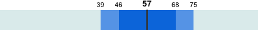

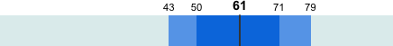

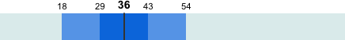

Funding Amount

$5.25m

$9.5m

$9.5m

Expected Cost

$2.99m

$5.8m

$3.42m

**Performance**

All Activations (%)

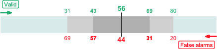

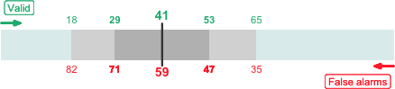

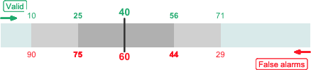

All Shocks (%)

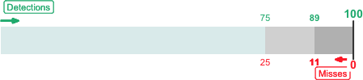

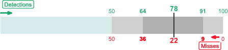

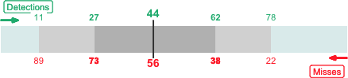

Notes

Expected cost computed using most likely probability of activation (central value). Triggers 1 and 2 can reach their threshold and activate independently from one another. Trigger 3 can only be met if Trigger 2 was not met. See Annex for performance metrics per timepoint. Trigger performance assessed by comparing recommended activations with historical bad years (i.e., years with a shock). ‘Bad years’ were identified through convergence of evidence from data on cereal deficit, millet production, food insecurity, fodder needs, and farmer surveys.

## Activation Scenarios

This section examines the likelihood of activation in a given year under various scenarios. The estimates are presented as confidence intervals to illustrate their inherent uncertainty. The graphs show how likely it is that a scenario will occur (darker inner band, 68% of years) as well as the highest and lowest probability that a scenario is to occur (full coloured band, 95% of years).

**Activations**

Yearly Disbursements<sup>1</sup>

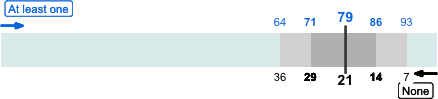

**Disbursement Scenario Breakdown**

Full<sup>2</sup>

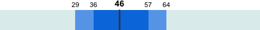

Package 1 only<sup>3</sup>

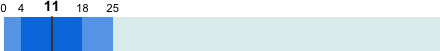

Package 2 only<sup>4</sup>

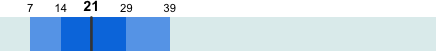

Notes

<sup>1</sup> Any: At least one trigger is met. None: No trigger is met.

<sup>2</sup> A full activation occurs when Triggers 1 and 2 are met, or when Triggers 1 and 3 are met, and both packages are disbursed.

<sup>3</sup> Package 1 is activated when Trigger 1 is met.

<sup>4</sup> Package 2 is activated when Trigger 2 or Trigger 3 is met. Historically Package 2 disbursement (19 instances) was triggered by the predictive trigger (Trigger 2) 89% of the time and by the observational trigger (Trigger 3) 11% of the time.

## Technical Team

The Département de la statistique du Niger, the Direction de la météorologie nationale du Niger, IRI Columbia University, the World Food Programme, and the Food and Agriculture Orgnization have provided data and/or analytical support. A total of 9 historical occurrences of severe shocks were documented and used to develop the trigger mechanism. Historical data and analysis are available through IRI’s Maproom [tool](http://iridl.ldeo.columbia.edu/fbfmaproom2/niger). The triggers were developed by IRI in close collaboration with DMN, WFP Niger, and the Centre for Humanitarian Data with valuable input from participating agencies and OCHA.

## Monitoring Process

Between January and June inclusively, the FIT team at IRI updates the forecast (Triggers 1 and 2) and the decision tool within Maproom by the 22nd of each month. Within 24 hours of the update, the IRI team notifies the AA team, the Niger Humanitarian Coordinator, and the Chief of CERF by email whether or not the trigger is met. By 7 August the Direction de la météorologie nationale du Niger will collate the rainfall measurements from the stations specified in the framework for the period 1 June - 31 July, and share them with the IRI FIT team. By 10 August the IRI FIT team will confirm the number of stations for which complete data is available; select ENACTS (80% or more available) or CHIRP (less than 80% available) accordingly; compute the SPI values and update Maproom. The IRI FIT team will then notify the AA team, the Niger Humanitarian Coordinator, and the Chief of CERF by email whether or not the trigger is met. In case of an activation, additional meteorological data will be shared by the DMN, the IRI FIT team, and/or Centre for Humanitarian Data to inform response targeting.

## Learning Opportunities

This table summarises the decisions, assumptions, and open questions that arose during trigger development. They are documented for transparency and to inform the learning agenda.

[output not shown]

## Annex

This table reports the performance metrics per activation timepoint for the triggers that have more than one opportunities for activation.

January

February

March

Prob. being met (%)

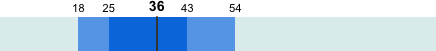

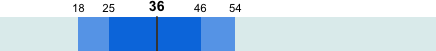

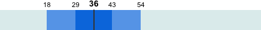

All Activations (%)

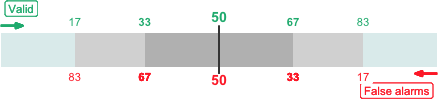

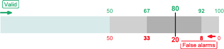

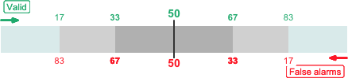

All Shocks (%)

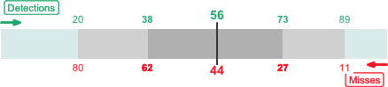

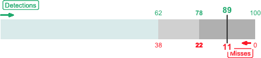

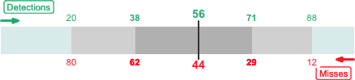

April

May

June

Prob. being met (%)

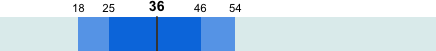

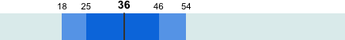

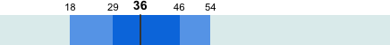

All Activations (%)

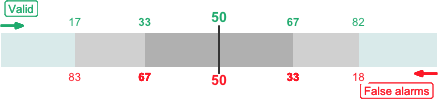

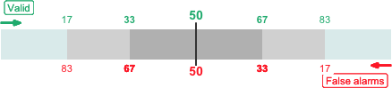

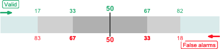

All Shocks (%)

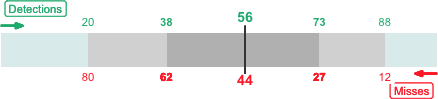

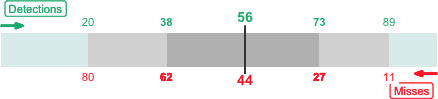

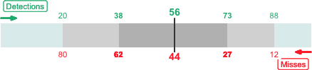